# **13. Sensitivity testing of acute temperature stress curve**

To evaluate uncertainty around how acute temperature stress influences fish fitness outcomes we performed a sensitivity analysis of the acute temperature stress curve. Sensitivity tests were based on a typical recent temperature year (2017) for the Columbia River. The effect of changing the shape of the temperature stress survival curve was measured on percent mortality. Two different curves were evaluated: an exponential relationship with LC10 and LC50 values from Jager et al. 2011 (exponential) and a curve defined in Sullivan et al. 2000 (logistic). The default acute temperature stress equation was based on the curve from the InStream model (Railsback et al. 2009). We compared three thermalscapes to the current thermalscape with CWRs: current year 2017 Columbia River temperatures without CWRs, warmer Columbia River (year 2017 +1°C), and warmer Columbia River (year 2017 +1°C without CWRs). We modeled the Grande Ronde Summer Steelhead population because of their large range in propensity to behaviorally thermoregulate.

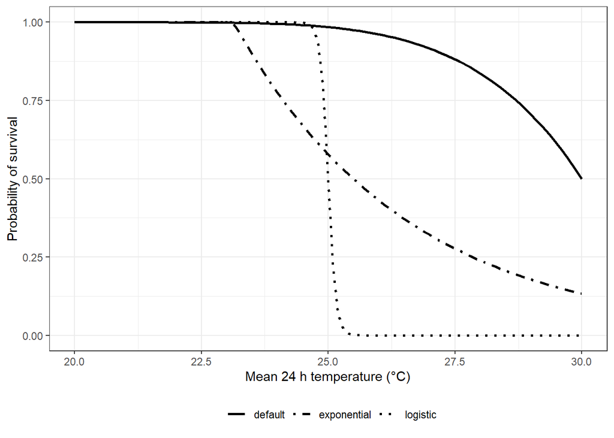

Fig. 13.1 Acute temperature stress curves tested in sensitivity experiment.

Table 13.1 Model output for percent of individuals dying from acute temperature stress summarized for Grande Ronde River Summer Steelhead.

| Scenario | Total mortality |
| --- | --- |
| Current (2017), Default | 0.2 |
| Current (2017), Logistic | 0.0 |
| Future (2017), Logistic | 0.0 |
| Future (2017) no CWR, Logistic | 0.0 |
| Current (2017), Exponential | 0.0 |
| Future (2017), Exponential | 18.9 |
| Future (2017) no CWR, Exponential | 28.0 |
| Future (2017) no CWR, Default | 1.9 |
| Future (2017), Default | 1.1 |
| Current (2017) no CWR, Exponential | 0.1 |
| Current (2017) no CWR, Logistic | 0.0 |
| Current (2017) no CWR, Default | 0.5 |